# UWPCE-DS1-Asst2-JStearns.Rmd

Jim Stearns

18 October 2014

# Assignment 2, Introduction to Data Science, UW PCE, Fall 2014

> For all assignment items, use the patterns described in:
> - DataScience02a.R
> - DataScience02b.R
> - DataScience02c.R

# 1. Using R Data Preparation

## a. Get Indian Liver Patient Dataset:

```r
url <- "http://archive.ics.uci.edu/ml/machine-learning-databases/00225/Indian%20Liver%20Patient%20Dataset%20(ILPD).csv"
ILPD.df<-read.csv(url,header=FALSE,stringsAsFactors=FALSE)
str(ILPD.df)
```

```
## 'data.frame':    583 obs. of  11 variables:
##  $ V1 : int  65 62 62 58 72 46 26 29 17 55 ...
##  $ V2 : chr  "Female" "Male" "Male" "Male" ...
##  $ V3 : num  0.7 10.9 7.3 1 3.9 1.8 0.9 0.9 0.9 0.7 ...
##  $ V4 : num  0.1 5.5 4.1 0.4 2 0.7 0.2 0.3 0.3 0.2 ...
##  $ V5 : int  187 699 490 182 195 208 154 202 202 290 ...
##  $ V6 : int  16 64 60 14 27 19 16 14 22 53 ...
##  $ V7 : int  18 100 68 20 59 14 12 11 19 58 ...
##  $ V8 : num  6.8 7.5 7 6.8 7.3 7.6 7 6.7 7.4 6.8 ...
##  $ V9 : num  3.3 3.2 3.3 3.4 2.4 4.4 3.5 3.6 4.1 3.4 ...
##  $ V10: num  0.9 0.74 0.89 1 0.4 1.3 1 1.1 1.2 1 ...
##  $ V11: int  1 1 1 1 1 1 1 1 2 1 ...
```

## b. Get the column headers

> From http://archive.ics.uci.edu/ml/datasets/ILPD+(Indian+Liver+Patient+Dataset)#

So I got the information manually. Copied and pasted, here it is:

Attribute Information:

1. Age Age of the patient
2. Gender Gender of the patient
3. TB Total Bilirubin
4. DB Direct Bilirubin
5. Alkphos Alkaline Phosphotase
6. Sgpt Alamine Aminotransferase
7. Sgot Aspartate Aminotransferase
8. TP Total Protiens
9. ALB Albumin
10. A/G Ratio Albumin and Globulin Ratio
11. Selector field used to split the data into two sets (labeled by the experts)

More detail on the 11th field, Selector: “Selector is a class label used to divide into groups(liver patient or not).”

## c. Manually construct a vector of column names.

```r
headers <- c("Age", "Gender", "TB", "DB", "Alkphos", "Sgpt", "Sgot", "TP", "ALB", "A/G Ratio", "Selector")
```

Most of the names provided by the study authors are valid R names. But the slash and space in “A/G Ratio” look iffy. Use an R method that coerces names to syntactically valid names.

```r
valid_headers <- make.names(headers)
valid_headers
```

```
##  [1] "Age"       "Gender"    "TB"        "DB"        "Alkphos"
##  [6] "Sgpt"      "Sgot"      "TP"        "ALB"       "A.G.Ratio"
## [11] "Selector"
```

## d. Associate names with the dataframe

```r
names(ILPD.df) <- valid_headers
str(ILPD.df)
```

```
## 'data.frame':    583 obs. of  11 variables:
##  $ Age      : int  65 62 62 58 72 46 26 29 17 55 ...
##  $ Gender   : chr  "Female" "Male" "Male" "Male" ...
##  $ TB       : num  0.7 10.9 7.3 1 3.9 1.8 0.9 0.9 0.9 0.7 ...
##  $ DB       : num  0.1 5.5 4.1 0.4 2 0.7 0.2 0.3 0.3 0.2 ...
##  $ Alkphos  : int  187 699 490 182 195 208 154 202 202 290 ...
##  $ Sgpt     : int  16 64 60 14 27 19 16 14 22 53 ...
##  $ Sgot     : int  18 100 68 20 59 14 12 11 19 58 ...
##  $ TP       : num  6.8 7.5 7 6.8 7.3 7.6 7 6.7 7.4 6.8 ...
##  $ ALB      : num  3.3 3.2 3.3 3.4 2.4 4.4 3.5 3.6 4.1 3.4 ...
##  $ A.G.Ratio: num  0.9 0.74 0.89 1 0.4 1.3 1 1.1 1.2 1 ...
##  $ Selector : int  1 1 1 1 1 1 1 1 2 1 ...
```

# 2.Using R Data Exploration on ILPD

## a. Use **head(ILPD)** to view the first six rows.

```r
head(ILPD.df, n=6)
```

```
##   Age Gender   TB  DB Alkphos Sgpt Sgot  TP ALB A.G.Ratio Selector
## 1  65 Female  0.7 0.1     187   16   18 6.8 3.3      0.90        1
## 2  62   Male 10.9 5.5     699   64  100 7.5 3.2      0.74        1
## 3  62   Male  7.3 4.1     490   60   68 7.0 3.3      0.89        1
## 4  58   Male  1.0 0.4     182   14   20 6.8 3.4      1.00        1
## 5  72   Male  3.9 2.0     195   27   59 7.3 2.4      0.40        1
## 6  46   Male  1.8 0.7     208   19   14 7.6 4.4      1.30        1
```

## b. Determine the mean, median, and standard deviation of each column

The Gender column is of type character (“Male”, “Female”). Let’s convert it to an integer so that mean etc calculations can be performed on it.

```r
ILPD.df$Gender <- as.integer(as.factor(ILPD.df$Gender))
str(ILPD.df)
```

```
## 'data.frame':    583 obs. of  11 variables:
##  $ Age      : int  65 62 62 58 72 46 26 29 17 55 ...
##  $ Gender   : int  1 2 2 2 2 2 1 1 2 2 ...
##  $ TB       : num  0.7 10.9 7.3 1 3.9 1.8 0.9 0.9 0.9 0.7 ...
##  $ DB       : num  0.1 5.5 4.1 0.4 2 0.7 0.2 0.3 0.3 0.2 ...
##  $ Alkphos  : int  187 699 490 182 195 208 154 202 202 290 ...
##  $ Sgpt     : int  16 64 60 14 27 19 16 14 22 53 ...
##  $ Sgot     : int  18 100 68 20 59 14 12 11 19 58 ...
##  $ TP       : num  6.8 7.5 7 6.8 7.3 7.6 7 6.7 7.4 6.8 ...
##  $ ALB      : num  3.3 3.2 3.3 3.4 2.4 4.4 3.5 3.6 4.1 3.4 ...
##  $ A.G.Ratio: num  0.9 0.74 0.89 1 0.4 1.3 1 1.1 1.2 1 ...
##  $ Selector : int  1 1 1 1 1 1 1 1 2 1 ...
```

```r
# R is 1-relative, so the values assigned here are 1 and 2. Make that 0 (Female) and 1 (Male)
ILPD.df$Gender <- ILPD.df$Gender - 1
str(ILPD.df)
```

```
## 'data.frame':    583 obs. of  11 variables:
##  $ Age      : int  65 62 62 58 72 46 26 29 17 55 ...
##  $ Gender   : num  0 1 1 1 1 1 0 0 1 1 ...
##  $ TB       : num  0.7 10.9 7.3 1 3.9 1.8 0.9 0.9 0.9 0.7 ...
##  $ DB       : num  0.1 5.5 4.1 0.4 2 0.7 0.2 0.3 0.3 0.2 ...
##  $ Alkphos  : int  187 699 490 182 195 208 154 202 202 290 ...
##  $ Sgpt     : int  16 64 60 14 27 19 16 14 22 53 ...
##  $ Sgot     : int  18 100 68 20 59 14 12 11 19 58 ...
##  $ TP       : num  6.8 7.5 7 6.8 7.3 7.6 7 6.7 7.4 6.8 ...
##  $ ALB      : num  3.3 3.2 3.3 3.4 2.4 4.4 3.5 3.6 4.1 3.4 ...
##  $ A.G.Ratio: num  0.9 0.74 0.89 1 0.4 1.3 1 1.1 1.2 1 ...
##  $ Selector : int  1 1 1 1 1 1 1 1 2 1 ...
```

First pass at calculations:

```r
sapply(ILPD.df, mean)
```

```
##       Age    Gender        TB        DB   Alkphos      Sgpt      Sgot
##   44.7461    0.7564    3.2988    1.4861  290.5763   80.7136  109.9108
##        TP       ALB A.G.Ratio  Selector
##    6.4832    3.1419        NA    1.2864
```

```r
sapply(ILPD.df, median)
```

```
##       Age    Gender        TB        DB   Alkphos      Sgpt      Sgot
##      45.0       1.0       1.0       0.3     208.0      35.0      42.0
##        TP       ALB A.G.Ratio  Selector
##       6.6       3.1        NA       1.0
```

```r
sapply(ILPD.df, sd)
```

```
##       Age    Gender        TB        DB   Alkphos      Sgpt      Sgot
##   16.1898    0.4296    6.2095    2.8085  242.9380  182.6204  288.9185
##        TP       ALB A.G.Ratio  Selector
##    1.0855    0.7955        NA    0.4525
```

A.G.Ratio returns a NA, which usually indicates at least one value is NA.

```r
print(sprintf("The number of NA values in A.G.Ratio = %d", sum(is.na(ILPD.df$A.G.Ratio))))
```

```
## [1] "The number of NA values in A.G.Ratio = 4"
```

Finesse the NA problem by specifying NA values are to be removed before the mean et al are calculated:

```r
sapply(ILPD.df, mean, na.rm=TRUE)
```

```
##       Age    Gender        TB        DB   Alkphos      Sgpt      Sgot
##   44.7461    0.7564    3.2988    1.4861  290.5763   80.7136  109.9108
##        TP       ALB A.G.Ratio  Selector
##    6.4832    3.1419    0.9471    1.2864
```

```r
sapply(ILPD.df, median, na.rm=TRUE)
```

```
##       Age    Gender        TB        DB   Alkphos      Sgpt      Sgot
##     45.00      1.00      1.00      0.30    208.00     35.00     42.00
##        TP       ALB A.G.Ratio  Selector
##      6.60      3.10      0.93      1.00
```

```r
sapply(ILPD.df, sd, na.rm=TRUE)
```

```
##       Age    Gender        TB        DB   Alkphos      Sgpt      Sgot
##   16.1898    0.4296    6.2095    2.8085  242.9380  182.6204  288.9185
##        TP       ALB A.G.Ratio  Selector
##    1.0855    0.7955    0.3196    0.4525
```

## c. What does **na.rm=TRUE** do in sd(x, **na.rm=TRUE**)?

Skip rows that have a N/A value (applied above).

## d. Create Histograms (**hist**) for each column where possible.

```r
str(ILPD.df)
```

```
## 'data.frame':    583 obs. of  11 variables:
##  $ Age      : int  65 62 62 58 72 46 26 29 17 55 ...
##  $ Gender   : num  0 1 1 1 1 1 0 0 1 1 ...
##  $ TB       : num  0.7 10.9 7.3 1 3.9 1.8 0.9 0.9 0.9 0.7 ...
##  $ DB       : num  0.1 5.5 4.1 0.4 2 0.7 0.2 0.3 0.3 0.2 ...
##  $ Alkphos  : int  187 699 490 182 195 208 154 202 202 290 ...
##  $ Sgpt     : int  16 64 60 14 27 19 16 14 22 53 ...
##  $ Sgot     : int  18 100 68 20 59 14 12 11 19 58 ...
##  $ TP       : num  6.8 7.5 7 6.8 7.3 7.6 7 6.7 7.4 6.8 ...
##  $ ALB      : num  3.3 3.2 3.3 3.4 2.4 4.4 3.5 3.6 4.1 3.4 ...
##  $ A.G.Ratio: num  0.9 0.74 0.89 1 0.4 1.3 1 1.1 1.2 1 ...
##  $ Selector : int  1 1 1 1 1 1 1 1 2 1 ...
```

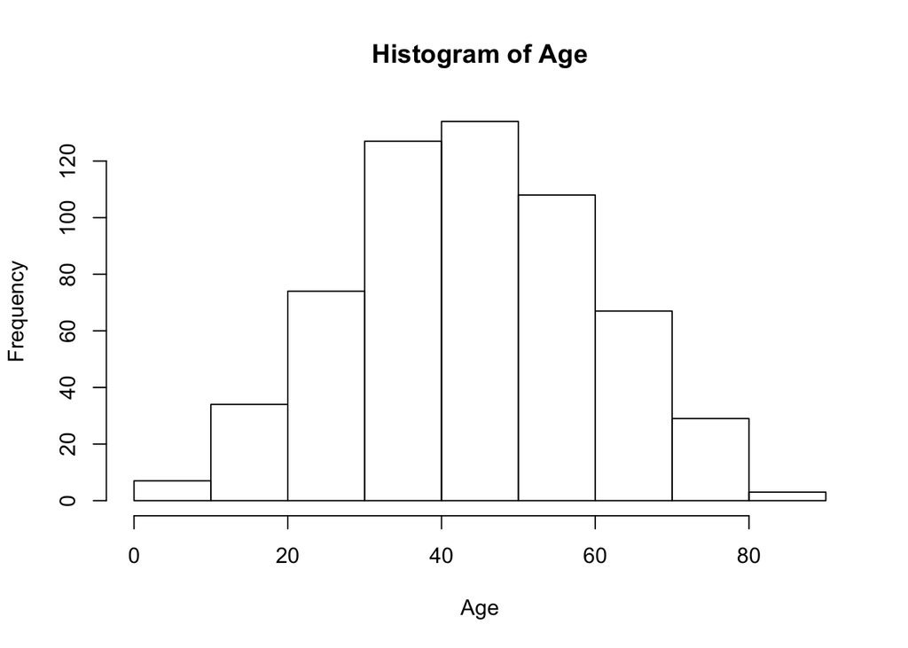

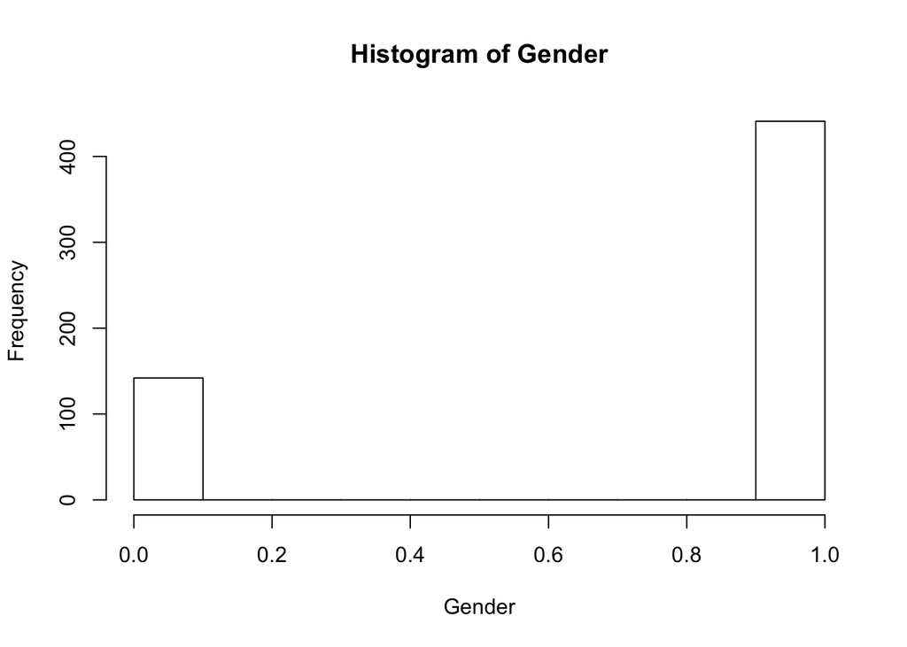

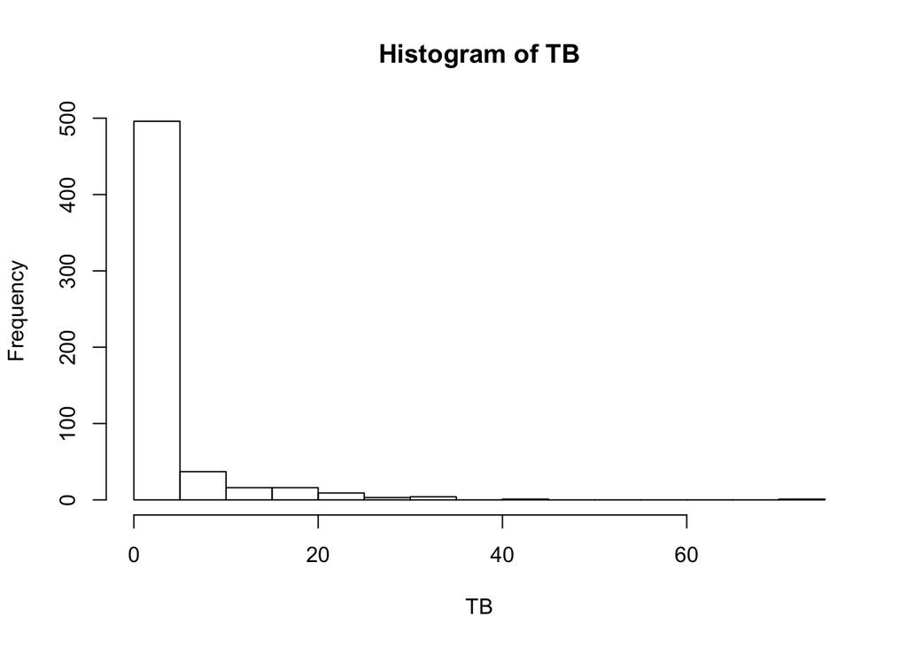

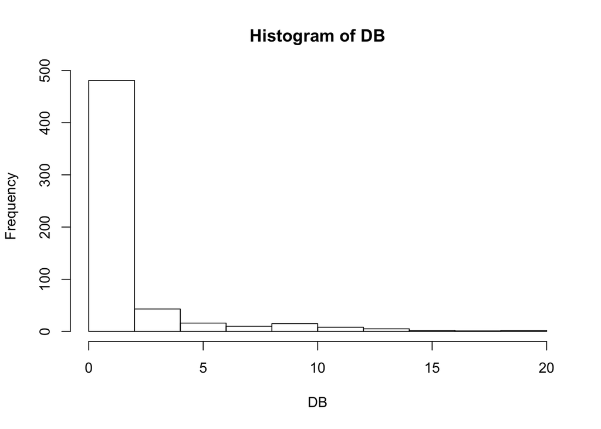

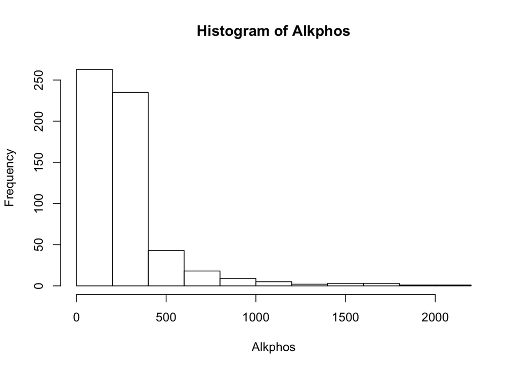

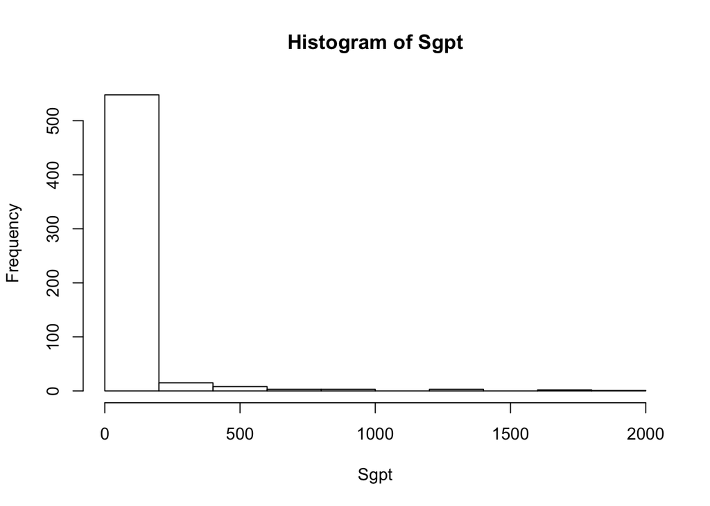

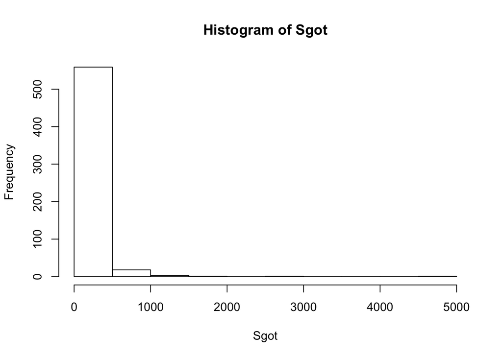

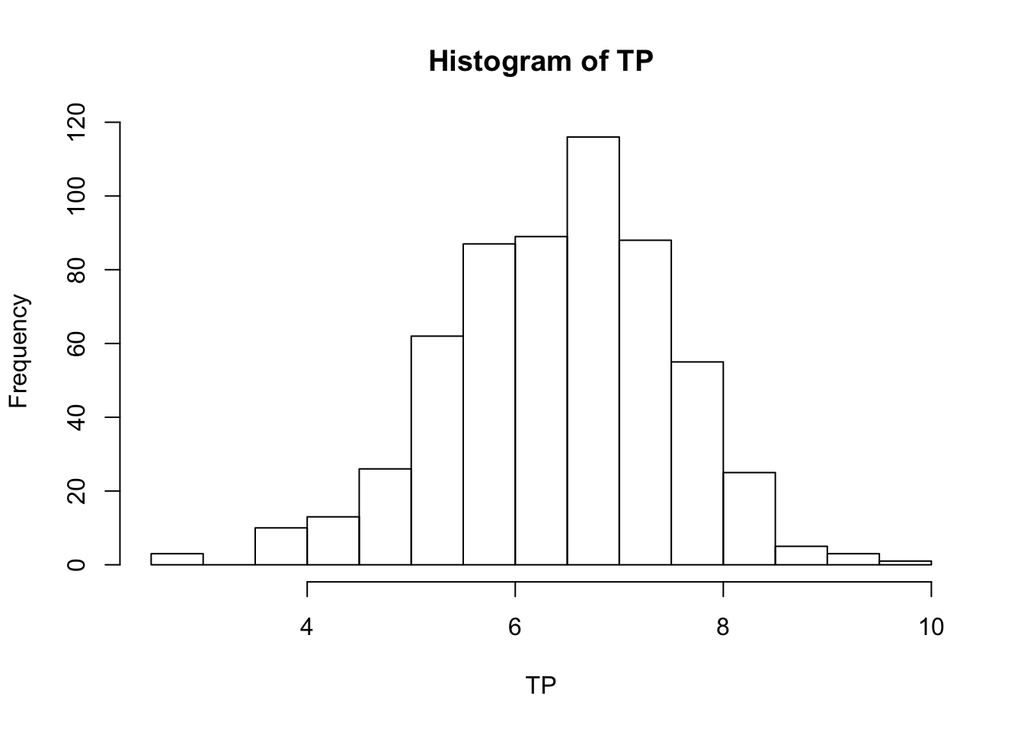

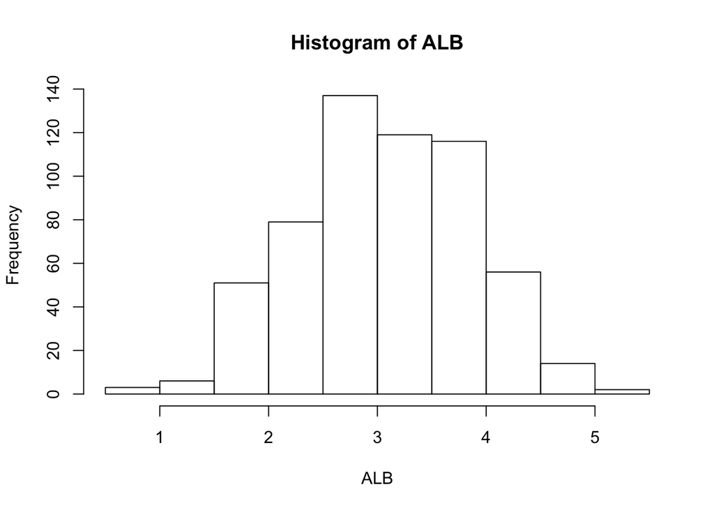

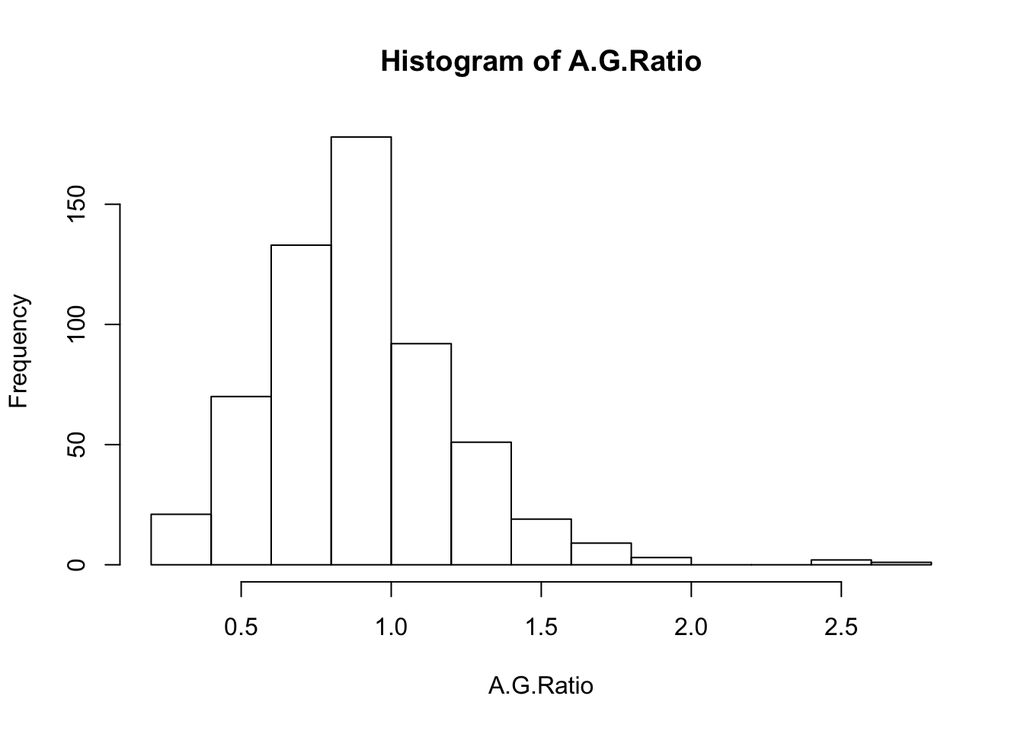

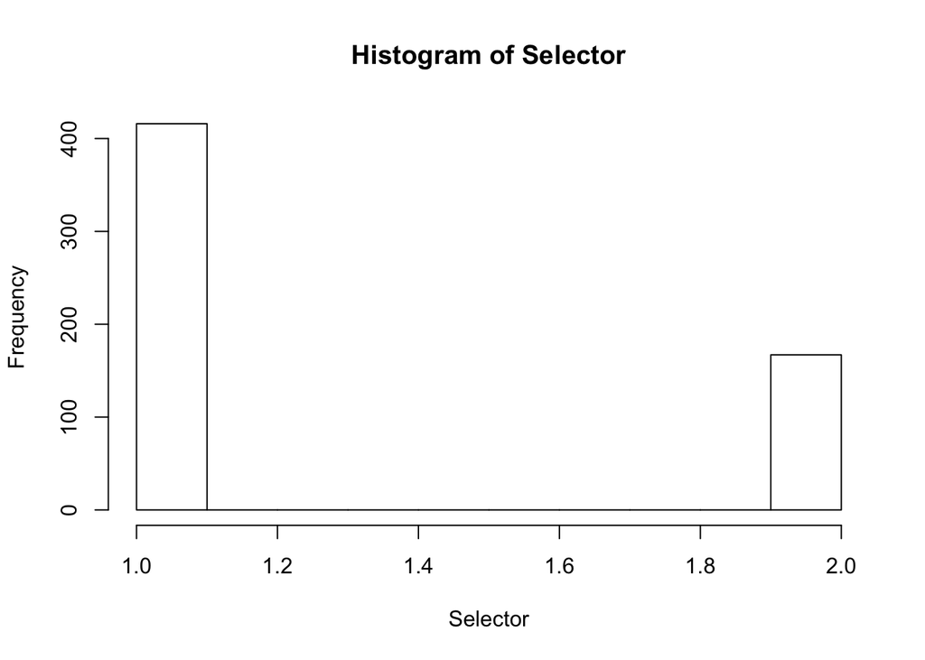

```r
par(mfrow=c(1,1))
for (col in seq(1, ncol(ILPD.df))) {
    xname <- names(ILPD.df)[col]
    hist(ILPD.df[,col], xlab=xname, main=paste("Histogram of", xname))
}
```

## e. Use the **plot(ILPD)** function to present a general overview of the data.

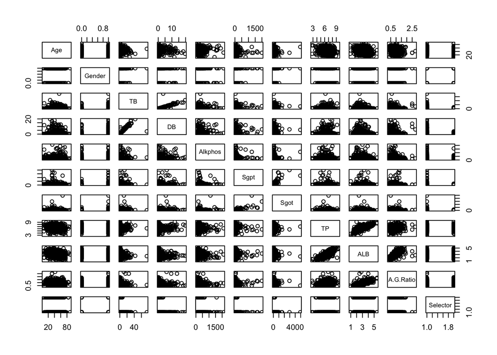

```r
par(mfrow=c(1,1))
plot(ILPD.df)
```

```r
# And plot to a PDF file so one can blow it up easily:
pdf("PlotILPD.pdf", width=7, height=7)
plot(ILPD.df)
dev.off()
```

> You want to see a matrix of many plots. Your efforts may be thwarted because the Gender column is not numeric. You can skip the Gender column, or you can turn the gender column into a numeric column. You might need help from a fellow student, the LinkedIn group, or me. Look at the plots and answer:

## e-a. What can you say about the data?

- Three pairs of predictors show a strong correlation - noted below.
- While 75% of the subjects are male, despite this weighting of male subjects, men are more likely to have high concentrations of Sgpt (Alamine Aminotransferase).
- The plot of two bi-modal variables - Gender and Selection - yield 4 unhelpfully similar arcs in the four corners. Whether any correlation exists between gender and status as a liver patient requires further analysis.

## e-b. How can you tell if a vector contains continuous numbers or binary data?

Binary data is bimodal. Continuous number are more distributed. Gender and Selector are bimodal, and binary.

## e-c. How can you tell if two vectors are correlated?

On a 2D plot of the two vectors, are the observations roughly linear?

Looking at the plot output, one can see that TB:DB, TP:ALB and ALB:A.G.Ratio seem to be correlated.

# 3. Using Data Preparation Concepts

> Create examples of the following data preparation processes in R:

## a. Remove Outliers

```r
testList <- c(-1, 1, 5, 1, 1, 17, -3, 1, 1, 3)
highLimit <- mean(testList) + 2*sd(testList)
lowLimit <- mean(testList) - 2*sd(testList)
goodFlag <- (testList < highLimit) & (testList > lowLimit)

print(sprintf("List with outliers removed: %s", paste(testList[goodFlag], collapse=", ")))
```

```
## [1] "List with outliers removed: -1, 1, 5, 1, 1, -3, 1, 1, 3"
```

```r
print(sprintf("Outliers removed: %s", paste(testList[!goodFlag], collapse=", ")))
```

```
## [1] "Outliers removed: 17"
```

## b. Relabel

```r
degree <- c('BS', 'MS', 'PhD', 'HS', 'Bachelors', 'Masters', 'High School', 'BS', 'MS', 'MS')
str(degree)
```

```
##  chr [1:10] "BS" "MS" "PhD" "HS" "Bachelors" "Masters" ...
```

```r
highSchoolDegrees=c("High School", "HS")
collegeDegrees=c("BS", "Bachelors")
graduateDegrees=c("MS", "PhD", "Masters")
degree[degree %in% highSchoolDegrees] <- "High School"
degree[degree %in% collegeDegrees] <- "College"
degree[degree %in% graduateDegrees ] <- "Graduate"
degree
```

```
##  [1] "College"     "Graduate"    "Graduate"    "High School" "College"
##  [6] "Graduate"    "High School" "College"     "Graduate"    "Graduate"
```

## c. Normalize: Min-Max and Z-score

```r
testVector <- c(-1, 1, 5, 1, 1, 17, -3, 1, 1, 3)

minMaxNormalize <- function(v) {
    minv <- min(v, na.rm=TRUE)
    maxv <- max(v, na.rm=TRUE)
    normv <- v - minv
    normv <- normv / (maxv - minv)
    return(normv)
}

zScoreNormalize <- function(v) {
    meanv <- mean(v, na.rm=TRUE)
    sdv <- sd(v, na.rm=TRUE)
    normv <- v - meanv
    normv <- normv / sdv
    return(normv)
}

testVectorMinMaxNormalized <- minMaxNormalize(testVector)
print(sprintf("Vector Min-Max normalized = %s",
              paste(testVectorMinMaxNormalized, collapse=", ")))
```

```
## [1] "Vector Min-Max normalized = 0.1, 0.2, 0.4, 0.2, 0.2, 1, 0, 0.2, 0.2, 0.3"
```

```r
testVectorZScoreNormalized <- zScoreNormalize(testVector)
print(sprintf("Vector Z-score normalized values (to two significant digits) = %s",
               paste(format(testVectorZScoreNormalized, digits=1), collapse=", ")))
```

```
## [1] "Vector Z-score normalized values (to two significant digits) = -0.66, -0.29,  0.44, -0.29, -0.29,  2.63, -1.02, -0.29, -0.29,  0.07"
```

## d. Binarize

```r
color <- c('Red', 'Green', 'Blue', 'Blue', 'Blue', 'Blue', 'Blue', 'Red', 'Green', 'Blue')

isRed <- color == 'Red'
isGreen <- color == 'Green'
isBlue <- color == 'Blue'

isRed <- as.numeric(isRed)
isGreen <- as.numeric(isGreen)
isBlue <- as.numeric(isBlue)
isRed
```

```
##  [1] 1 0 0 0 0 0 0 1 0 0
```

```r
isGreen
```

```
##  [1] 0 1 0 0 0 0 0 0 1 0
```

```r
isBlue
```

```
##  [1] 0 0 1 1 1 1 1 0 0 1
```

```r
# Make sure all vector elements have been accounted for - once
allThree <- isRed + isGreen + isBlue
allOnes <- rep(1, length(allThree))
allAccountedFor <- sum(allThree == allOnes) == length(allOnes)
print(sprintf("All vector elements accounted for - once == %s", allAccountedFor))
```

```
## [1] "All vector elements accounted for - once == TRUE"
```

```r
v <- c(3,4,4,5,5,5,5,5,5,5,5,6,6,6,6,6,7,7,7,7,8,8,9,12,23, 23, 25, 81)

NBINS = 3
range <- max(v) - min(v)
binWidth <- range / NBINS
bin2Min <- binWidth
bin3Min <- 2*binWidth

range
```

```
## [1] 78
```

```r
binWidth
```

```
## [1] 26
```

```r
bin2Min
```

```
## [1] 26
```

```r
bin3Min
```

```
## [1] 52
```

```r
vDiscretized <- rep(NA, length(v))
vDiscretized[v < bin2Min] <- "Low"
vDiscretized[v >= bin2Min & v < bin3Min] <- "Medium"
vDiscretized[v >= bin3Min] <- "High"
print(sprintf("Vector discretized into three bins: %s", paste(vDiscretized, collapse=", ")))
```

```
## [1] "Vector discretized into three bins: Low, Low, Low, Low, Low, Low, Low, Low, Low, Low, Low, Low, Low, Low, Low, Low, Low, Low, Low, Low, Low, Low, Low, Low, Low, Low, Low, High"
```